# Diagnosi di malattia cardiaca tramite Decision Tree

Enrico Moioli

14/11/2024

# 1. Introduzione

Il dataset “Heart Disease” disponibile nel UCI Machine Learning Repository [**qui**](https://archive.ics.uci.edu/dataset/45/heart+disease) contiene 303 soggetti e 14 variabili, tra cui età, sesso, pressione sanguigna, livelli di colesterolo e glucosio. L’obiettivo di tale dataframe, è prevedere la presenza di malattie cardiache con una variabile target con valori 0 (assenza) e 1 (presenza). È ampiamente utilizzato per compiti di classificazione in ambito medico e sanitario.

**Definizione del quesito sperimentale**

Quali variabili demografiche, fisiologiche e biologiche presenti nel dataset “Heart Disease” sono i migliori predittori per la presenza di malattia cardiaca nei soggetti analizzati?

**Metodo**

Attraverso l’indagine di quali siano le variabili più strettamente collegate alle malattie cardiache, si mira alla creazione di un modello di machine learning predittivo.

# 2. Analisi delle caratteristiche e delle relazioni del dataframe:

```
##  [1] "età"                  "genere"               "dolore_toracico"
##  [4] "pressione_sanguigna"  "colesterolo"          "glicemia"
##  [7] "ecg"                  "frequenza_cardiaca"   "angina_da_esercizio"
## [10] "depressione_st"       "pendenza_st"          "numero_vasi_colorati"
## [13] "talassemia"           "diagnosi"
```

| Variabile | Tipo | Descrizione |
| --- | --- | --- |
| età | Numerica | Età del paziente |
| genere | Categoriale | Sesso del paziente (1 = maschio, 0 = femmina) |
| dolore_toracico | Categoriale | Tipo di dolore toracico (0 = nessun dolore, 1 = poco, 2 = molto, 3 = estremo) |
| pressione_sanguigna | Numerica | Pressione sanguigna a riposo (mm Hg) |
| colesterolo | Numerica | Livello di colesterolo nel sangue (mg/dl) |
| glicemia | Categoriale | Zucchero nel sangue a digiuno (> 120 mg/dl) |
| ecg | Categoriale | Elettrocardiogramma a riposo (0 = normale, 1 = anomalo, 2 = grave) |
| frequenza_cardiaca | Numerica | Frequenza cardiaca massima raggiunta durante l’esercizio |
| angina_da_esercizio | Categoriale | Angina indotta dall’esercizio (1 = sì, 0 = no) |
| depressione_st_indotta | Numerica | Depressione del segmento ST indotta dall’esercizio rispetto al riposo |
| pendenza_st | Categoriale | Pendenza del segmento ST durante l’esercizio (1, 2, 3) |
| numero_vasi_colorati | Numerica | Numero di vasi principali (0-3) visibili con fluoroscopia |
| talassemia | Categoriale | Condizione di thalassemia (1 = normale, 2 = difetto reversibile, 3 = difetto irreversibile) |
| diagnosi | Target | Diagnosi di malattia cardiaca (0 = assente, 1 = presente) |

**Variabile Target**

| diagnosi | n | % |
| --- | --- | --- |
| 0 | 138 | 45.54455 |
| 1 | 165 | 54.45545 |

*Nel dataset, il **45,5%** dei soggetti non presenta malattia cardiaca, mentre il **54,5%** dei soggetti presenta malattia cardiaca.*

*Dopo aver rinominato e verificato eventuali N.A. proseguo rendendo fattoriali le variabili adatte.*

Prime 7 righe del dataframe

| età | genere | dolore_toracico | pressione_sanguigna | colesterolo | glicemia | ecg | frequenza_cardiaca | angina_da_esercizio | depressione_st | pendenza_st | numero_vasi_colorati | talassemia | diagnosi |
| --- | --- | --- | --- | --- | --- | --- | --- | --- | --- | --- | --- | --- | --- |
| 63 | M | Estremo | 145 | 233 | Alta | Normale | 150 | No | 2.3 | 0 | 0 | Normale | Presente |
| 37 | M | Molto | 130 | 250 | Nella norma | Anomalo | 187 | No | 3.5 | 0 | 0 | Difetto Reversibile | Presente |
| 41 | F | Poco | 130 | 204 | Nella norma | Normale | 172 | No | 1.4 | 2 | 0 | Difetto Reversibile | Presente |
| 56 | M | Poco | 120 | 236 | Nella norma | Anomalo | 178 | No | 0.8 | 2 | 0 | Difetto Reversibile | Presente |
| 57 | F | Nessun Dolore | 120 | 354 | Nella norma | Anomalo | 163 | Sì | 0.6 | 2 | 0 | Difetto Reversibile | Presente |
| 57 | M | Nessun Dolore | 140 | 192 | Nella norma | Anomalo | 148 | No | 0.4 | 1 | 0 | Normale | Presente |
| 56 | F | Poco | 140 | 294 | Nella norma | Normale | 153 | No | 1.3 | 1 | 0 | Difetto Reversibile | Presente |

*Procedo poi con qualche grafico che metta in luce eventuali relazioni.*

##2.1 Grafici

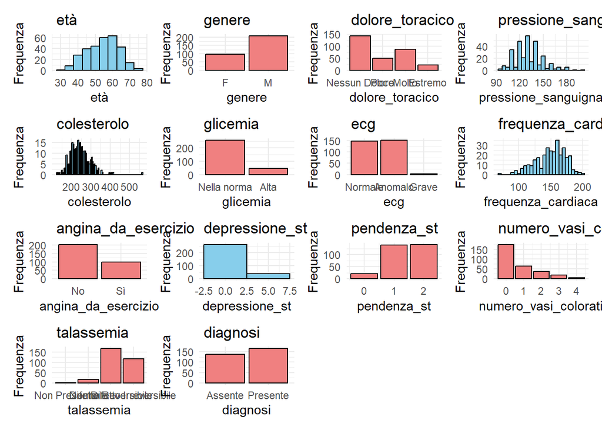

**Risultati:**

*Dai grafici possiamo dedurre che il nostro campione:*

- *è composto principalmente da uomini,*
- *la distribuzione dei dati nelle variabili numeriche tende a disporsi su una curva normale,*

## 2.2 Relazioni fra le variabili numeriche e la variabile target

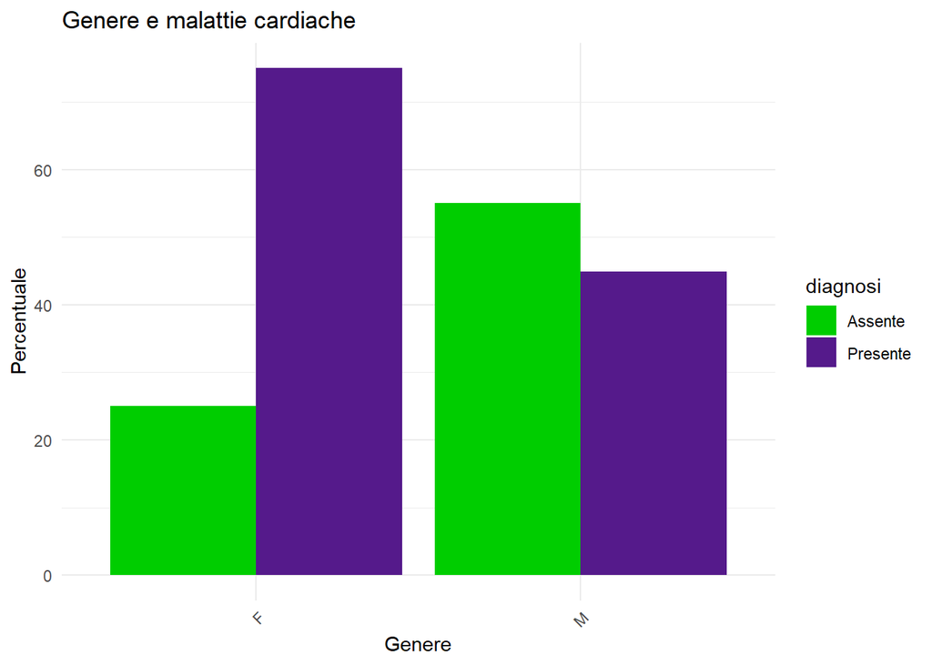

*Le donne sono percentualmente più a rischio di malattia cardiaca.*

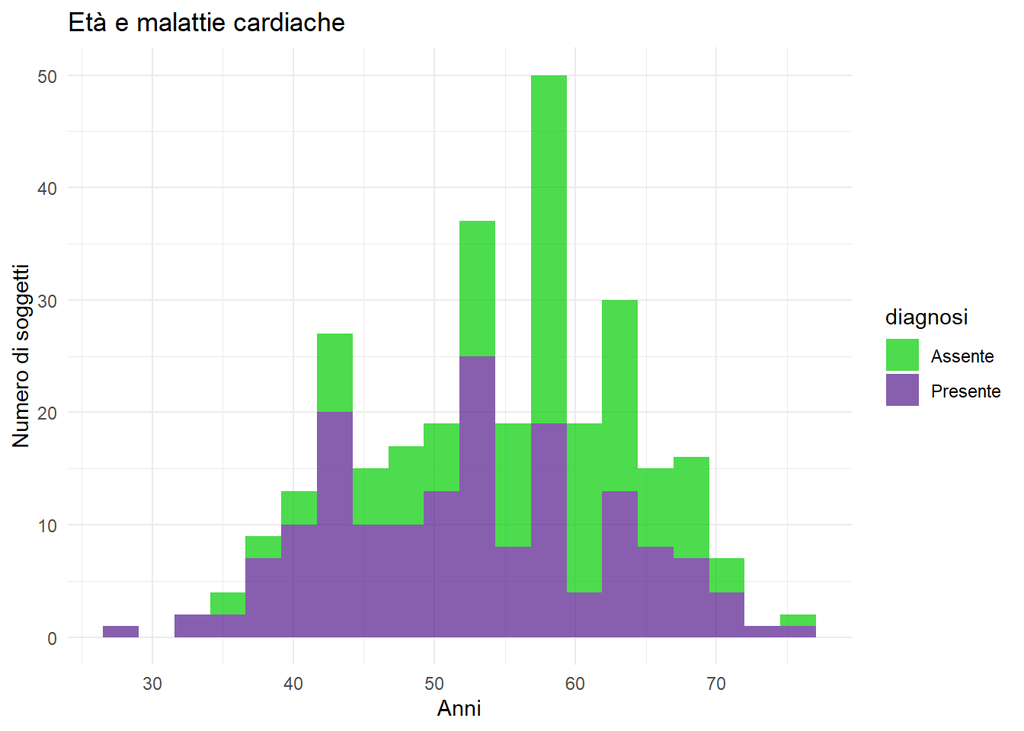

*I soggetti sono principalmente fra i 35 e i 70 anni di età, con proporzioni fra malati e sani che tendono ad invertirsi dopo i 55 anni.*

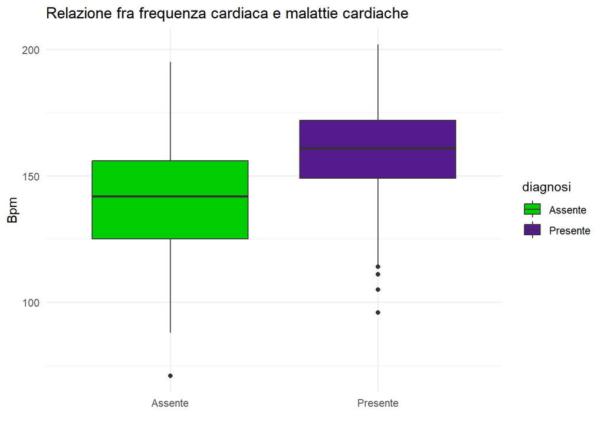

*I soggetti malati hanno una frequenza cardiaca massima mediamente superiore.*

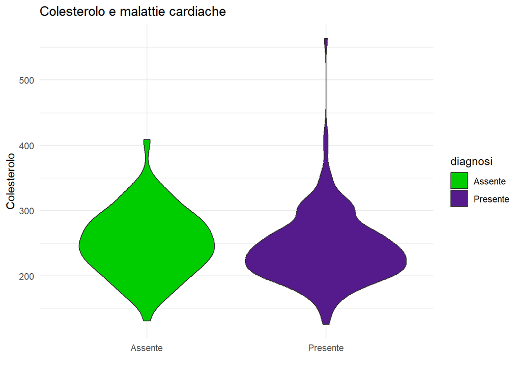

*Valori di colesterolo estremamente alti sono solo nei soggetti malati.*

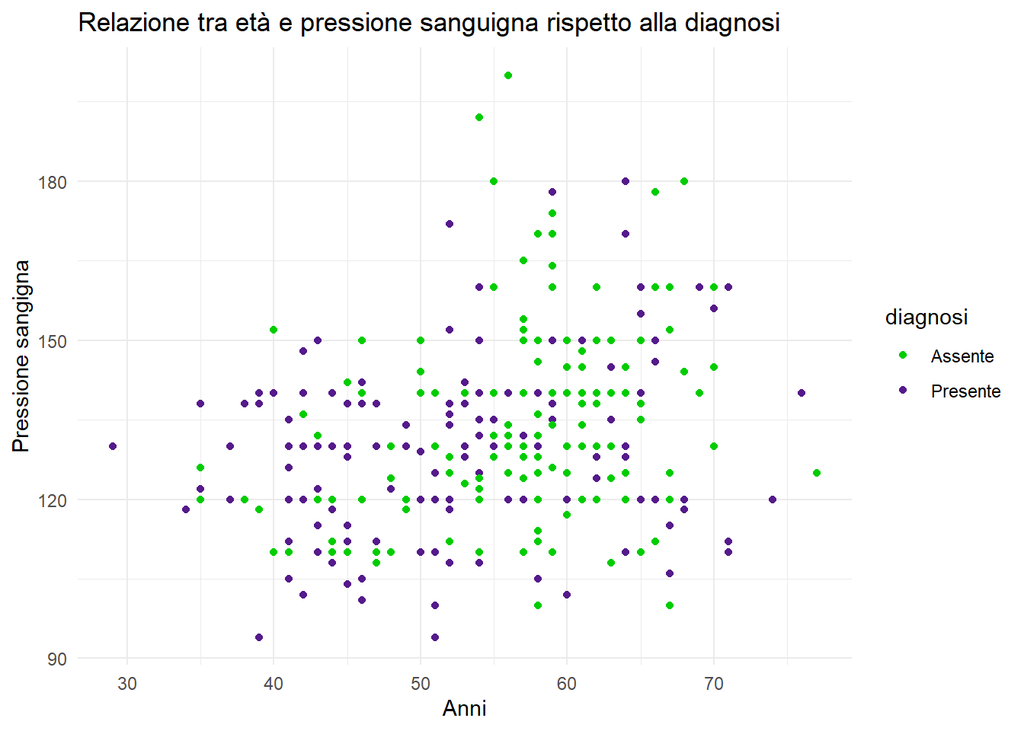

*I soggetti giovani sembrano mediamente più affetti che quelli over 55.*

```
## [1] 0.2793509
```

*La relazione fra età e pressione sanguigna è debole.*

## 2.3 Correlazioni fra le variabili numeriche

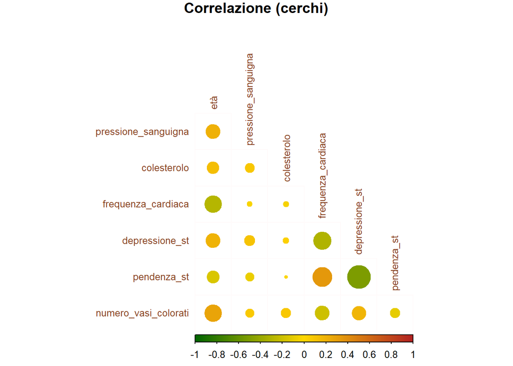

*Si noti il triangolo di correlazioni fra pendenza del segmento st, frequenza cardiaca e depressione del segmento st.*

# 3. Machine Learning

*Dopo aver preparato la Recipe per il mio algoritmo, vado a creare un Machine Learning. Visto anche il numero di variabili categoriche appare indicato il Decision Tree per la variabile Target dicotomica.*

```r
# Specifico il modello "Decision Tree"
tree_spec <- decision_tree() %>%
  set_engine("rpart") %>%
  set_mode("classification")

# Creo il workflow unendo il recipe e il modello
tree_workflow <- workflow() %>%
  add_recipe(tree_recipe) %>%
  add_model(tree_spec)

# CROSS VALIDATION
tree_results <- tree_workflow %>%
  fit_resamples(resamples = data_cv,
    control = control_resamples(save_pred = TRUE, verbose = TRUE),
    metrics = metric_set(roc_auc, accuracy)
  )

# Raccolgo i risultati
tree_results %>%
  collect_metrics()
```

```
## # A tibble: 2 × 6
##   .metric  .estimator  mean     n std_err .config
##   <chr>    <chr>      <dbl> <int>   <dbl> <chr>
## 1 accuracy binary     0.801    10  0.0169 Preprocessor1_Model1
## 2 roc_auc  binary     0.838    10  0.0229 Preprocessor1_Model1
```

```r
# Training finale
tree_wf_fit <- tree_workflow %>%
  fit(data = data_train)

# Estraggo il modello
tree_fit <- tree_wf_fit %>%
  extract_fit_parsnip()
```

*Dopo l’addestramento possiamo finalmente vedere il nostro albero decisionale:*

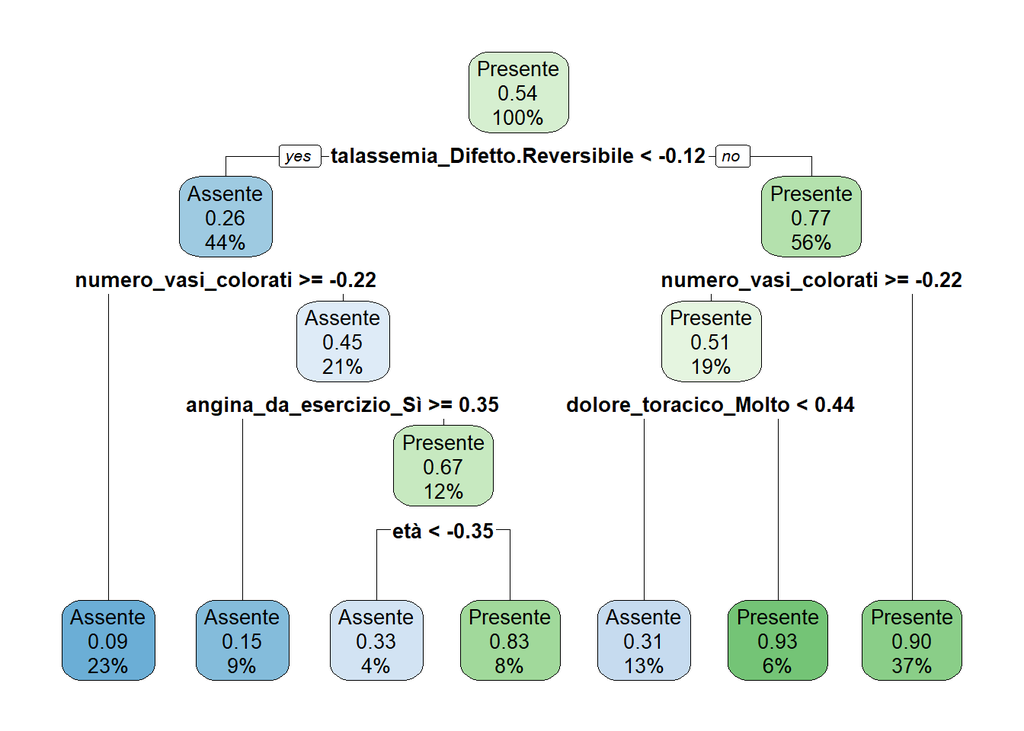

*Nonostante alcune foglie del nostro albero contengano basse percentuali, i valori delle foglie verdi (.83, .93, .90) indicano buone capacità di individuare i soggetti con una cadiopatia.*

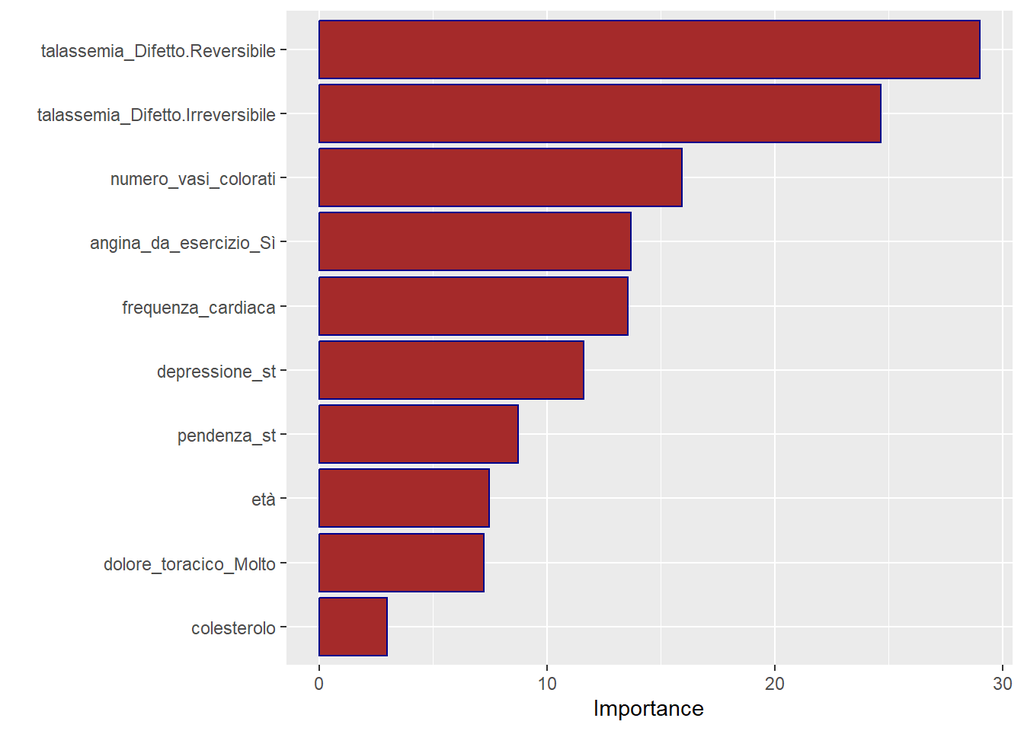

*Questo grafico a barre mostra le variabili che influenzano maggiormente le decisioni del modello.* *La reversibilità o meno della talassemia e il numero di vasi principali visibili con fluoroscopia risultano esserene i primi tre predittori.*

*Verifichiamo ora le metriche del modello creato:*

Metriche del modello (Accuratezza e AUC)

| .metric | .estimator | mean | n | std_err | .config |
| --- | --- | --- | --- | --- | --- |
| accuracy | binary | 0.801 | 10 | 0.017 | Preprocessor1_Model1 |
| roc_auc | binary | 0.838 | 10 | 0.023 | Preprocessor1_Model1 |

*Seppure non ottimali, i valori di precisione e di area sotto la curva roc sono entrambi superiori a .80 indicano che il modello è in grado di distinguere tra le classi con una buona performance.*

### 3.1 Verifica di performance sui dati test

*Proseguendo con il test del modello, otteniamo i seguenti risultati:*

```
## # A tibble: 3 × 4
##   .metric     .estimator .estimate .config
##   <chr>       <chr>          <dbl> <chr>
## 1 accuracy    binary         0.818 Preprocessor1_Model1
## 2 roc_auc     binary         0.879 Preprocessor1_Model1
## 3 brier_class binary         0.134 Preprocessor1_Model1
```

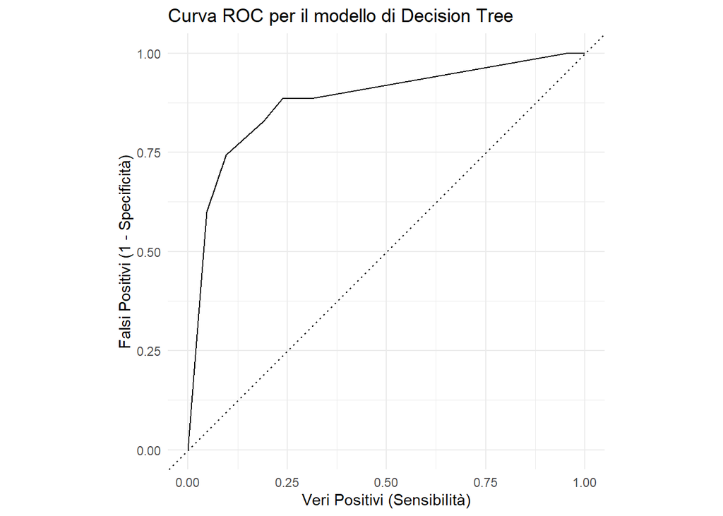

*Vediamo la **matrice di confusione** per analizzare meglio i risultati ottenuti:*

```
##           Truth
## Prediction Assente Presente
##   Assente       31       10
##   Presente       4       32
```

*I risultati del modello sui dati test sono buoni, possiamo tuttavia pensare a come migliorare.*

## 3.2 Tuning

*Per migliorare le prestazioni del modello, possiamo considerare il tuning dei parametri. In particolare, per l’albero decisionale:*

- tuning del parametro di potatura dell’albero (cost_complexity);
- profondità dell’albero (tree_depth);
- numero minimo di osservazioni per una divisione in un nodo (min_n).

*Definizione della griglia di tuning:*

```r
tree_spec_tuned <- decision_tree(
  cost_complexity = tune(),
  tree_depth = tune(),
  min_n = tune()
) %>%
  set_engine("rpart") %>%
  set_mode("classification")

grid <- grid_regular(
  cost_complexity(),
  tree_depth(),
  min_n(),
  levels = 5
)
```

*Aggiornamento del workflow e tuning:*

```r
tree_workflow_tuned <- workflow() %>%
  add_recipe(tree_recipe) %>%
  add_model(tree_spec_tuned)

tune_results <- tree_workflow_tuned %>%
  tune_grid(
    resamples = data_cv,
    grid = grid,
    metrics = metric_set(roc_auc, accuracy)
  )
```

*Visualizzazione dei risultati di tuning:*

```
## # A tibble: 125 × 9
##    cost_complexity tree_depth min_n .metric .estimator  mean     n std_err
##              <dbl>      <int> <int> <chr>   <chr>      <dbl> <int>   <dbl>
##  1    0.0000000001          4    11 roc_auc binary     0.843    10  0.0279
##  2    0.0000000178          4    11 roc_auc binary     0.843    10  0.0279
##  3    0.00000316            4    11 roc_auc binary     0.843    10  0.0279
##  4    0.000562              4    11 roc_auc binary     0.843    10  0.0279
##  5    0.0000000001          4    21 roc_auc binary     0.836    10  0.0226
##  6    0.0000000178          4    21 roc_auc binary     0.836    10  0.0226
##  7    0.00000316            4    21 roc_auc binary     0.836    10  0.0226
##  8    0.000562              4    21 roc_auc binary     0.836    10  0.0226
##  9    0.0000000001          8    21 roc_auc binary     0.836    10  0.0226
## 10    0.0000000178          8    21 roc_auc binary     0.836    10  0.0226
## # ℹ 115 more rows
## # ℹ 1 more variable: .config <chr>
```

*Visualizza i migliori modelli in base a ROC AUC e accuracy:*

```
## # A tibble: 5 × 9
##   cost_complexity tree_depth min_n .metric .estimator  mean     n std_err
##             <dbl>      <int> <int> <chr>   <chr>      <dbl> <int>   <dbl>
## 1    0.0000000001          4    11 roc_auc binary     0.843    10  0.0279
## 2    0.0000000178          4    11 roc_auc binary     0.843    10  0.0279
## 3    0.00000316            4    11 roc_auc binary     0.843    10  0.0279
## 4    0.000562              4    11 roc_auc binary     0.843    10  0.0279
## 5    0.0000000001          4    21 roc_auc binary     0.836    10  0.0226
## # ℹ 1 more variable: .config <chr>
```

```
## # A tibble: 5 × 9
##   cost_complexity tree_depth min_n .metric  .estimator  mean     n std_err
##             <dbl>      <int> <int> <chr>    <chr>      <dbl> <int>   <dbl>
## 1    0.0000000001          8    11 accuracy binary     0.814    10  0.0194
## 2    0.0000000178          8    11 accuracy binary     0.814    10  0.0194
## 3    0.00000316            8    11 accuracy binary     0.814    10  0.0194
## 4    0.000562              8    11 accuracy binary     0.814    10  0.0194
## 5    0.0000000001         11    11 accuracy binary     0.814    10  0.0194
## # ℹ 1 more variable: .config <chr>
```

*Purtroppo risulta difficile individuare un modello ottimo per entrambi i valori di ROC AUC e accuracy.*

*Selezione del migliore modello per accuracy e finalizzazione del modello:*

```
## # A tibble: 1 × 4
##   cost_complexity tree_depth min_n .config
##             <dbl>      <int> <int> <chr>
## 1    0.0000000001          8    11 Preprocessor1_Model036
```

Metriche del modello Preprocessor1_Model036 (Accuratezza e AUC)

| cost_complexity | tree_depth | min_n | .metric | .estimator | mean | n | std_err | .config |
| --- | --- | --- | --- | --- | --- | --- | --- | --- |
| 0 | 8 | 11 | accuracy | binary | 0.814 | 10 | 0.019 | Preprocessor1_Model036 |
| 0 | 8 | 11 | roc_auc | binary | 0.834 | 10 | 0.029 | Preprocessor1_Model036 |

*Il nostro modello con valore accuracy più alto risulta avere profondità **8** e numero minimo di soggetti **11**; con valori di accuracy .814 e roc_auc .834*

*Visualizzare l’albero decisionale:*

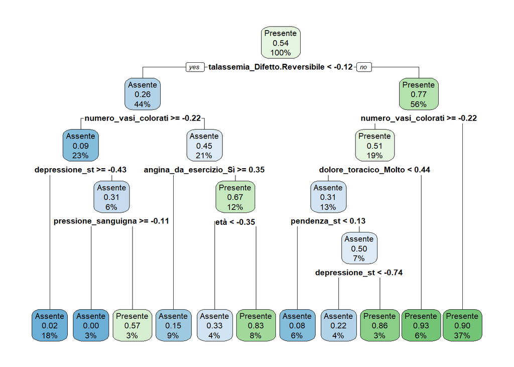

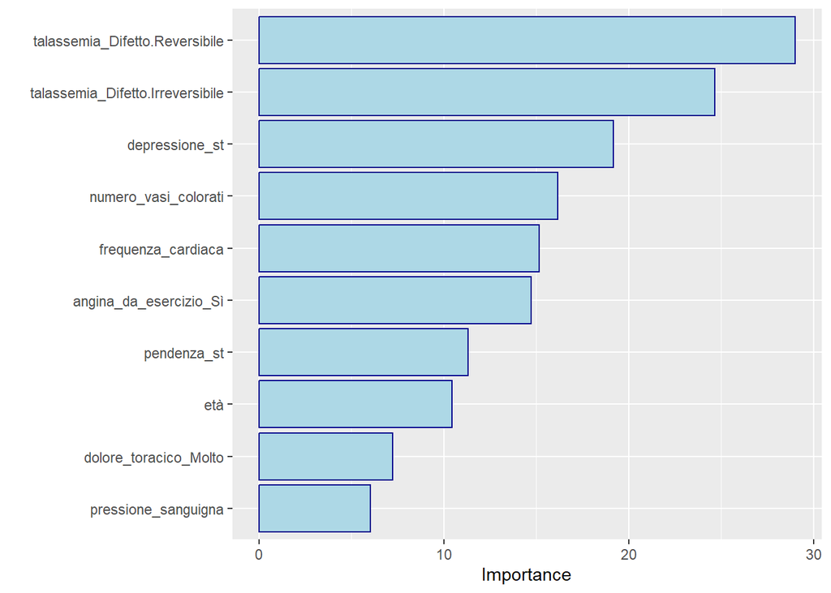

*In questo secondo modello, emerge l’importanza della variabile Depressione del segmento ST indotta dall’esercizio rispetto al riposo, che si posiziona al terzo posto.*

### 3.3 Seconda verifica di performance sui dati test (con tuning)

*Proseguendo con il test del modello sul dataset di test, otteniamo i seguenti risultati:*

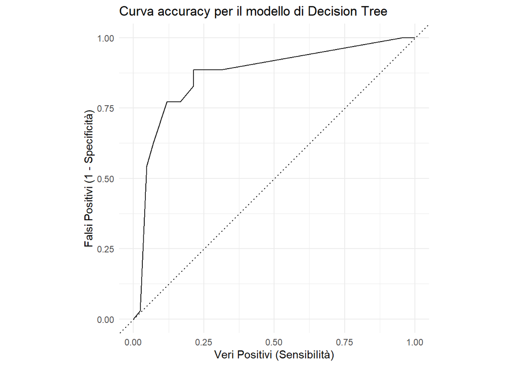

*Vediamo la **matrice di confusione** per analizzare meglio i risultati ottenuti:*

```
##           Truth
## Prediction Assente Presente
##   Assente       29        9
##   Presente       6       33
```

*Il tuning ha equilibrato i risultati relativi, ma ha peggiorato quelli assoluti, con 15 errori su 77.*

# 4. Conclusione

Il Decision Tree creato si comporta tutto sommato bene, anche se non ottimamente. Inoltre, il tuning ha cambiato leggermente i risultati ma non abbastanza da poterci ritenere soddisfatti. Plausibilmente altri modelli di Machine Learning o una ridefinizione del pool di variabili utilizzate nella ricetta dell’albero, potrebbero dare risultati più soddisfacenti.